# CSCI_E-89C_Final_part2

## Problem 1

Consider the optimal selection of a treatment. Suppose that there are 4 types of treatments available. The outcome of each treatment is either 1 (recovery) or 0.

Let's denote the outcome by $R_t$, then $R_t|(A_t=a)$ follows $\text{Bernoulli}(p_a)$ with $a\in\{1,2,3,4\}$ and all $p_a\in [0,1]$, where $A_t$ denotes the action on time step $t=1,2,3,\ldots$.

Assume that $p_1=0.05$, $p_2=0.15$, $p_3=0.55$, $p_4=0.85$, which are not known to the doctor. This is the 4-armed Bandit Problem with Bernoulli distributions. The rewards $R_t$ are 0's and 1's. Please notice that $P\{R_t=1|A_t=a\}=p_a$. Also, the expectation $E\left[R_t|A_t=a \right]=p_a$.

Develop the Upper-Confidence-Bound Action Selection algorithm for the problem of selecting the best treatment and report the following graphs:

(a) Run the algorithm for $t=1,2,3,\ldots,400$ and plot $R_t$'s v.s. $t$ for one simulation. Use $c=0.15$.  
(b) Run 100 trajectories in (a); and for each time step $t$ plot the average of $R_t$'s from all 100 trajectories at this particular time (please do not average all returns over time - we want to see how the learning progresses over time). Use $c=0.15$.  
(c) Using trajectories you obtained in (b), for each time step $t$, plot the proportion (out of 100) of times the best action (action $a=4$) was selected by the doctor. Again, use $c=0.15$.

```python
import numpy as np
import random
import pandas as pd
import time
import pickle

from matplotlib import pyplot as plt
from keras import layers
from keras import models
from keras.layers import Dropout
from keras.datasets import mnist
```

```
(a)
```

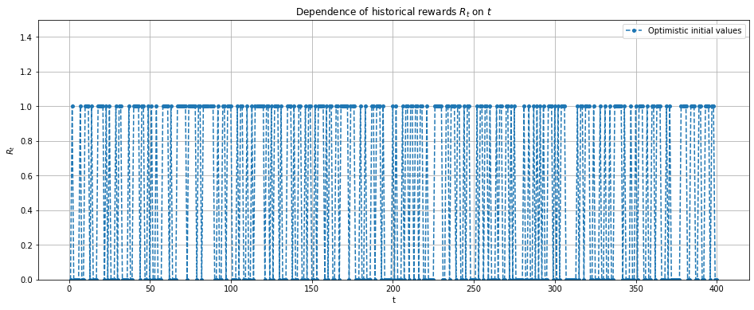

```
(b)
```

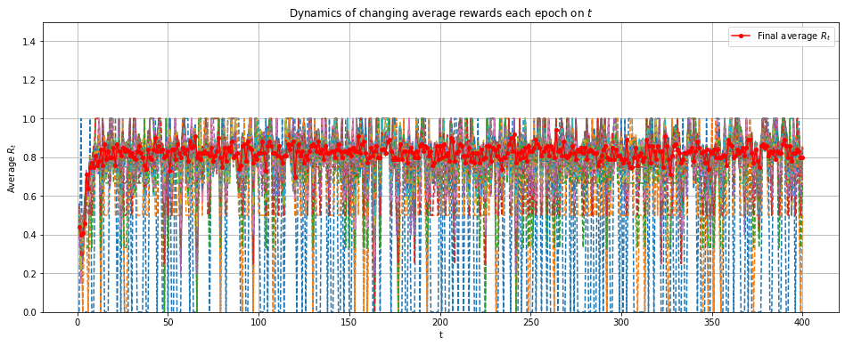

```
(c)
```

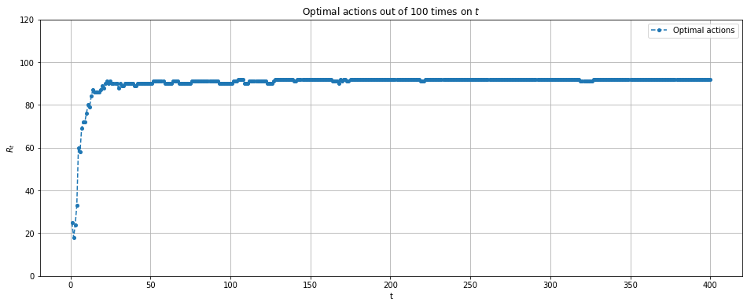

```python
#Midterm 1

class Environment:
    def __init__(self):
        self.time = 0

    def admissible_actions(self):
        return list(range(1,5))

    def get_reward(self, action):

        P = [[0.95,0.05],
             [0.85,0.15],
             [0.45,0.55],
             [0.15,0.85]]

        return np.random.choice([0,1], p = P[action-1])

class Agent:
    def __init__(self, k, c):
        self.current_reward = 0.0
        self.current_action = []
        self.k = k
        self.c = c
        self.Nt = np.zeros(k)
        self.Qt = np.zeros(k)

    def step(self, env):
        actions = env.admissible_actions()

        env.time += 1

        At = self.select_action(env, actions)
        Rt = env.get_reward(At)

        self.Nt[At-1] += 1
        self.Qt[At-1] += (Rt-self.Qt[At-1])/self.Nt[At-1]

        self.current_action = At
        self.current_reward = Rt


    def select_action(self, env, actions):

        Qs = []

        for action in actions:

            Q = 1e200

            if self.Nt[action-1] > 0:
                Q = self.Qt[action-1] + self.c*np.sqrt(np.log(env.time) / self.Nt[action-1])


            Qs.append(Q)


        unb_q = np.zeros(self.k)
        q_max = np.amax(Qs)
        idx = np.argwhere(Qs == q_max)

        for a in range(0, self.k):
            if Qs[a]==q_max:
                unb_q[a] = 1/len(idx)
            else:
                unb_q[a] = 0

        return np.random.choice(actions, p = unb_q)


def rewards_hist(T=10, k=10, c=2, alpha=None):
    env = Environment()
    agent = Agent(k, c)
    rewards = []
    b_actions = []
    while env.time < T:
        agent.step(env)
        rewards.append(agent.current_reward)
        if agent.current_action == 4:
            b_actions.append(1)
        else:
            b_actions.append(0)

    return np.asarray(rewards), b_actions



T = 400
k = 4
c = 0.15

epochs = 100

#all_rewards = []
avg_rewards = []
all_actions = []
for i in range(1, epochs+1):
    Rs,As = rewards_hist(T, k, c)
    if i == 1:

        print("(a)")

        plt.figure(figsize=(16,6))
        plt.plot(range(1,T+1),Rs, linestyle='--', marker='o', markersize=4, label='Optimistic initial values')
        plt.xlabel("t")
        plt.ylabel("$R_t$")
        plt.title('Dependence of historical rewards $R_t$ on $t$')
        plt.ylim(0, 1.5)
        plt.grid(True)
        plt.legend(loc = 'upper right')
        plt.show()

#        all_rewards.append(Rs)
        avg_rewards.append(Rs)
        all_actions = As
    else:
        Rm = avg_rewards[i-2]
#        all_rewards.append(Rs)
        avg_rewards.append(np.add(Rm,(Rs-Rm)/i))
        all_actions = np.add(all_actions, As)

#all_rewards = np.asarray(all_rewards)

avg_rewards = np.asarray(avg_rewards)
avg_reward = avg_rewards[epochs-1]


print ("(b)")

plt.figure(figsize=(16,6))
#
#Plotting rewards for all 100 epochs in one figure is not feasible
#plt.plot(range(1,T+1),np.transpose(all_rewards), linestyle='--', marker=None, markersize=10)
#
#Instead plotting average rewards after running new epoch
plt.plot(range(1,T+1),np.transpose(avg_rewards), linestyle='--', marker=None, markersize=10)
plt.plot(range(1,T+1),avg_reward, linestyle='-', marker="o",color = "r", markersize=4, label='Final average $R_t$')
plt.xlabel("t")
plt.ylabel("Average $R_t$")
plt.title('Dynamics of changing average rewards each epoch on $t$')
plt.ylim(0, 1.5)
plt.grid(True)
plt.legend(loc = 'upper right')
plt.show()


print("(c)")

plt.figure(figsize=(16,6))
plt.plot(range(1,T+1),all_actions, linestyle='--', marker='o', markersize=4, label='Optimal actions')
plt.xlabel("t")
plt.ylabel("$R_t$")
plt.title('Optimal actions out of 100 times on $t$')
plt.ylim(0, 120)
plt.grid(True)
plt.legend(loc = 'upper right')
plt.show()
```

## Problem 2

Consider Environment that has five states: 1, 2, 3, 4, and 5. Possible transitions are: (1) 1->1, 1->2; (2) 2->1, 2->2, 2->3; (3) 3->2, 3->3, 3->4; (4) 4->3, 4->4, 4->5; (5) 5->4, 5->5.

Actions of the Agent are decoded by -1, 0, and +1, which correspond to its intention to move left, stay, and move right, respectively. The Environment, however, does not always respond to these intentions exactly, and there is 10% chance that action 0 will result in moving to the right (if moving to the right is admissible), and -1 action will result in staying - in other words, there is a "west wind." More specifically, the non-zero transition probabilities $p(s^\prime,r|s,a)$ are

$p(s^\prime=1,r=0|s=1,a=0)=0.9, p(s^\prime=2,r=0|s=1,a=0)=0.1$,  
$p(s^\prime=2,r=0|s=1,a=+1)=1$,

$p(s^\prime=1,r=0|s=2,a=-1)=0.9, p(s^\prime=2,r=0|s=2,a=-1)=0.1$,  
$p(s^\prime=2,r=0|s=2,a=0)=0.9,p(s^\prime=3,r=-10|s=2,a=0)=0.1$,  
$p(s^\prime=3,r=-10|s=2,a=+1)=1$,

$p(s^\prime=2,r=0|s=3,a=-1)=0.9,p(s^\prime=3,r=-10|s=3,a=-1)=0.1$,  
$p(s^\prime=3,r=-10|s=3,a=0)=0.9,p(s^\prime=4,r=0|s=3,a=0)=0.1$,  
$p(s^\prime=4,r=0|s=3,a=+1)=1$,

etc.

Further, we assume that whenever the process enters state 3, the Environment generates reward = -10. In all other cases the reward is 0. For example, transition 2->3 will result in reward -10, transition 3->3 will result in reward -10, transition 3->2 will result in reward 0, transition 2->2 will result in reward 0, etc.

Further, assume that the agent does not know about the wind or what rewards to expect. It chooses to stay in all states, i.e. the policy is $\pi(-1|1)=0, \pi(0|1)=1, \pi(+1|1)=0$,  
$\pi(-1|2)=0, \pi(0|2)=1, \pi(+1|2)=0$,  
$\pi(-1|3)=0, \pi(0|3)=1, \pi(+1|3)=0$,  
$\pi(-1|4)=0, \pi(0|4)=1, \pi(+1|4)=0$,  
etc.

Please estimate the state-value function using 2-step Temporal Difference (TD) prediction. Let’s use $\gamma=0.9$ and run the episodes for $T=100$.

```python
class Environment:

    def admissible_actions(self, state):
        A = list((-1,0,1))
        if state == 1: A.remove(-1)
        if state == 5: A.remove(1)
        return A

    def get_reward(self, S, A):
        if S == 3:
            return -10

        return 0

    def new_state(self, S,A):

        if A == 1:
            return S+1
        elif S == 5 and A == 0:
            return S
        else:
            return np.random.choice([S+A,S+A+1], p=[0.9,0.1])


def gen_episode(S, A, T=100):
    env = Environment()
    states = []
    actions = []
    rewards = []
    for t in range(T+1):
        S = env.new_state(S,A)
        states.append(S)
        actions.append(A)
        R = env.get_reward(S,A)
        rewards.append(R)
    return [states, actions, rewards]

episodes = []

def nstepTD(n=1, alpha=0.01, gamma=0.9, T=10, nepisodes=5000):
    alpha = 0.01
    gamma = 0.9
    T = 100
    V = np.zeros(5)

    for k in range(nepisodes):
        S0 = random.randrange(1, 6)
        A0 = 0
        episode = gen_episode(S0, A0, T)
        episodes.append(episode)
        for t in range(0,T-n+1):
            S = episode[0][t]
            Sn = episode[0][t+n]
            G = 0
            for tau in reversed(range(t,t+n)):
                R = episode[2][tau]
                G = R + gamma*G
            G = G + gamma**n*V[Sn-1]
            V[S-1] = V[S-1] + alpha*(G - V[S-1])

    return V


V = nstepTD(n=2, alpha=0.02, gamma=0.9, T=100, nepisodes=50000)
print("alpha =",alpha,"\nV:\n",V)
```

```
alpha = 0.02
V:
 [-11.99669786 -24.2222189  -50.86281316   0.           0.        ]
```

## Problem 3

In this problem, we consider the optimization of hospital patient flow using the Markov Decision Process. We assume that the hospital can hold 300 patients at most.

Further, we introduce three states as follows:

"Low" if number of patients is in $[0,100)$  
"Medium" if number of patients is in $[101,200)$  
"High" if number of patients is in $[201,300]$

Please notice that this aggregation is an improtant step as it allows one to accuratly estimate the transition probabilities from state to state using the database that tracks journeys of patients through the hospital from arrival to discharge.

One time step corresponds to one day and the administration of the hospital can select the following actions:

If the hospital has "Low" number of patients, then $a \in \{0\}$, where $0$ indicates that no patient will be released early.  
If the hospital has "Medium" number of patients, then $a \in \{0,1\}$, i.e. besides action $a=0$, only one additional action is admissible, namely $1$. This action corresponds to releasing $10$ patients early.  
If the hospital has "High" number of patients, then $a \in \{0,1,2\}$, i.e. besides action $a=0$, two additional actions, namely $1$ and $2$, are admissible. Action $a=1$ again corresponds to releasing $10$ patients early, while action $2$ indicates releasing $20$ patients early.

Further, assume that we found the transition probabilities $p(S_{t+1}=s^\prime|S_t=s,A_t=a)$ to be (for a data-driven estimates refer, for instance, to "Markov Decision Process Model for Optimisation of Patient Flow" by Clissold, J. Filar, S. Qin, and D.Ward, 21st International Congress on Modelling and Simulation, Gold Coast, Australia, 29 Nov to 4 Dec 2015):

$p(S_{t+1}=s^\prime|S_t=s,A_t=0)=\begin{bmatrix} 0.8 & 0.2 & 0 \\ 0.25 & 0.7 & 0.05\\ 0.01 & 0.25 & 0.74\\ \end{bmatrix}$

Here, we use the Markov Chain convention with $s$ being the row index (in the order from "Low" to "Hight"), and $s^\prime$ being the column index.  
For example, $p(S_{t+1}=\text{"High"}|S_t=\text{"Medium"},A_t=0)=0.05$ and $p(S_{t+1}=\text{"Medium"}|S_t=\text{"Low"},A_t=0)=0.2$.

The reward $R_{t+1}$ obtained as a result of action $A_t$ is defined as follows:  
$R_{t+1}=\frac{1}{10}\left[\mathbb{1}_{\{S_{t+1}=\text{"Low"}\}}\cdot 49.5+\mathbb{1}_{\{S_{t+1}=\text{"Medium"}\}}\cdot 150.5+\mathbb{1}_{\{S_{t+1}=\text{"High"}\}}\cdot 255.5 + A_t\cdot (-10)\right]+\frac{9}{10}\left[\mathbb{1}_{\{S_{t+1}=\text{"High"}\}}\cdot (-30)\right]$.

Here, the first term $\frac{1}{10}\left[\ldots\right]$ is related to the direct profit of the hospital, while the second term $\frac{9}{10}\left[\ldots\right]$ is associated with the inconvenience of patients, risk of refusal for admission of new patients, and the reputation of the hospital.

Using this information, please find the optimal policy for the decision making via Double Q-learning. Use $\gamma=0.9$. Please treat this problem as a continuing task.

```python
Q = np.zeros((3,3))

Q[0] = [1.3,0,0]
Q[1] = [3.23,2.5,0]
Q[2] = [1.0,2.3,0.5]


a = [0]

print (Q[0][a])

#b = [0,2]

#for aa in a:
#    if aa not in b:
#        print (aa)


#print(np.intersect1d(a, b))
```

```
[1.3]
```

```python
#Double Q-learning

class Environment:
    def __init__(self, S0 = 1):
        self.time = 1
        #self.patients = 0
        self.state = S0

    def admissible_actions(self, state):

        if state == 1:
            return [0]
        elif state == 2:
            return [0,1]
        else:
            return [0,1,2]

    def new_state(self, S,A):

        p_A_S_nS = [[[0.8, 0.2, 0], [0.25, 0.7, 0.05],  [0.01, 0.25, 0.74]],
                    [[0, 0, 0],     [0.35, 0.61, 0.04], [0.02, 0.34, 0.64]],
                    [[0, 0, 0],     [0, 0, 0],          [0.03, 0.43, 0.54]]]


        return np.random.choice([1,2,3], p=p_A_S_nS[A][S-1])


    def get_reward(self, S, A):

        self.time += 1

        S_one = np.zeros((3))
        S_one[S-1] = 1
#        print("S_one",S_one)

#        R = 0.1*(49.5*S_one[0] + 150.5*S_one[1] + 255.5*S_one[2] - action*10) + 0.9*(-30*S_one[2])
        R = 4.95*S_one[0] + 15.05*S_one[1] - 1.45*S_one[2] - A

        return R



def update_policy(env, Q_1, Q_2, epsilon):

    P = np.zeros((3,3))

    Q = np.sum([Q_1,Q_2], axis=0)/2

    for S in range(1,4):
        actions = env.admissible_actions(S)
        idx_tmp = np.argwhere(Q[S-1] == np.amax(Q[S-1][actions]))[0]

        idx = np.intersect1d(actions, idx_tmp)

        for a in actions:
            if a not in idx:
                P[S-1][a] = epsilon/len(actions)



        Ps = sum(P[S-1])
        for ix in idx:
            P[S-1][ix] = (1-Ps)/len(idx)


    return P


def final_policy(Q_1, Q_2):

    P = np.zeros((3,3))

    Q = np.sum([Q_1,Q_2], axis=0)/2

    for S_i in range(0,3):
        P[S_i][np.argmax(Q[S_i])] = 1

    return P


def double_Q(gamma=0.9, alpha=0.1, epochs=100000, epsilon=0.05):

    env = Environment()

    Q_1 = np.zeros((3,3))
    Q_2 = np.zeros((3,3))

    P = update_policy(env, Q_1, Q_2, epsilon)

    S = random.randrange(1, 4)

    for i in range(0, epochs):

        #A = np.random.choice([0,1,2], p=P[S-1])#=0
        #print("S,P[S-1]",S,P[S-1])

    #    for t in range(1,T):

        A = np.random.choice([0,1,2], p=P[S-1])
        R = env.get_reward(S,A)
        S_ = env.new_state(S,A)
            #A_ = np.random.choice([0,1,2], p=P[S_-1])#=0
            #print("\nS,P[S_-1],A,R,S_",S,P[S_-1],A,R,S_)

            #print("Q_1[S-1][A],Q_2[S-1][A]",Q_1[S-1][A],Q_2[S-1][A])

        if random.randint(1, 2) == 1:
            Q_1[S-1][A] += alpha * (R + gamma * Q_2[S_-1][np.argmax(Q_1[S_-1])] - Q_1[S-1][A])
        else:
            Q_2[S-1][A] += alpha * (R + gamma * Q_1[S_-1][np.argmax(Q_2[S_-1])] - Q_2[S-1][A])

            #print("n Q_1[S-1][A],Q_2[S-1][A]",Q_1[S-1][A],Q_2[S-1][A])

            #print("P",P)
        P = update_policy(env, Q_1, Q_2, epsilon)
            #print("n P",P)


        S = S_
            #A = A_

#    print (Q_1, "\n", Q_2)

    P_final = final_policy(Q_1, Q_2)
    Q = np.sum([Q_1,Q_2], axis=0)/2

    return P_final, Q


gamma=0.9
alpha=0.05
#T=100
#n_trials=1000
epochs = 100000
epsilon = 0.05


P,Q = double_Q(gamma, alpha, epochs, epsilon)

print ("Final policy:\n",P, "\n\nAvg (Q_1,Q_2):\n",Q)
```

```
Final policy:
 [[1. 0. 0.]
 [1. 0. 0.]
 [0. 0. 1.]]

Avg (Q_1,Q_2):
 [[81.26226621  0.          0.        ]
 [98.04372177 94.96734143  0.        ]
 [63.14130688 61.54629664 70.51466186]]
```

## Problem 4

In this problem we will develop an algorithm for approximating state values using Deep Neural Network (NN). We consider images of size 28x28, which can be treated as vectors of 784 features: ${\bf x}=(x_1,x_2,\ldots,x_{784})^T$.

Please load the observations of features ${\bf x}(S_t)$, $t=0,1,\ldots$ ('images' variable), actions $A_t$, $t=0,1,\ldots$ ('actions' variable), and rewards $R_t$, $t=1,2,\ldots$ from the 'markov_decision_process.pkl' file. Please notice that in each state $s\in \mathcal{S}$, the set of admissible actions is $\mathcal{A}(s)=\{0,1,2\}$. Here, "0" states for no treatment and "1" and "2" are two treatments of different types. We assume that this is a Markov Decision Process, that is, the joint distribution of the next state $S_{t+1}$ and reward $R_{t+1}$ depens on the pair of current state and action $(S_t, A_t)$ only.

These rewards were obtained under uniform policy $\pi$, that is, actions were selected at random from the action space $\mathcal{A}(s)$. Please develop a 1-step TD prediction algorithm with approximation via a Deep NN to evaluate state values $v_\pi(s)$ under this pilicy $\pi$. Please use the vector of fetures ${\bf x}(S_t)$ as an input to the NN. The output of the NN should be the state-values $\hat{v}(S_t,{\bf w})$. Please feel free to use either feedforward fully connected NN or Convolutional NN.

Please

- train the NN in mini-batches of size 128, that is, the weights ${\bf w}$ will be updated every 128 time steps
- update the target $R_{t+1}+\gamma\hat{v}(S_{t+1},{\bf w})$ every 1280 time steps only, that is, not the most recent weights should be used to evaluate this taget - this usually guarantees a better stability of the algorithm

Once the training is finished, please pick 24 images at random and display them together with the estimated state values in the titles.

```python
with open('markov_decision_process.pkl', 'rb') as f:
    images_, actions, rewards = pickle.load(f)

images = images_.reshape(len(images_), 784)
images = images.astype('float32')

images /= 255
```

```python
model = models.Sequential()

#Input Layer with Shape (784,1) and Hidden Layer with 512 nodes
model.add(layers.Dense(512, activation='relu', input_shape=(784,)))
model.add(Dropout(0.2))
#Hidden Layer with 512 nodes
model.add(layers.Dense(512, activation='relu'))
model.add(Dropout(0.2))
#Output Q of size 3 [0,1,2]
model.add(layers.Dense(1, activation='linear'))

model.compile(loss='mse', optimizer='adam')

model.summary()
```

```
Model: "sequential_3"
_________________________________________________________________
Layer (type)                 Output Shape              Param #
=================================================================
dense_7 (Dense)              (None, 512)               401920
_________________________________________________________________
dropout_3 (Dropout)          (None, 512)               0
_________________________________________________________________
dense_8 (Dense)              (None, 512)               262656
_________________________________________________________________
dropout_4 (Dropout)          (None, 512)               0
_________________________________________________________________
dense_9 (Dense)              (None, 1)                 513
=================================================================
Total params: 665,089
Trainable params: 665,089
Non-trainable params: 0
_________________________________________________________________
```

```python
target_model = model
#target_model.set_weights(model.get_weights())


gamma = 0.9
epochs = 1

X = []
y = []

hist = []

V = 0

for idx in range(0,len(images)-1):

    S = images[idx]
#    A = actions[idx]
    R = rewards[idx]
#    R = rewards[idx+1]
    S_ = images[idx+1]

    #Vs = model.predict(np.array([S]))[0]
    Vp = target_model.predict(np.array([S_]))[0][0]

#    print(V,R)

    V = R + gamma*Vp

#    print(V)


    if (idx+1) % 1280 == 0:
#        print(idx+1,"/",len(images)-1)

        target_model.set_weights(model.get_weights())

        V = R


    X.append(S)
    y.append(V)

    if (idx+1) % 128 == 0:
        history = model.fit(np.array(X), np.array(y), epochs=epochs, verbose=1)
        X = []
        y = []

        h = history.history
        hist.append(h['loss'])

history = model.fit(np.array(X), np.array(y), epochs=epochs, verbose=1)



h = history.history

#print (h)
hist.append(h['loss'])
print(idx+1,"/",len(images)-1)
print("Training finished")
```

```
49999 / 49999
Training finished
```

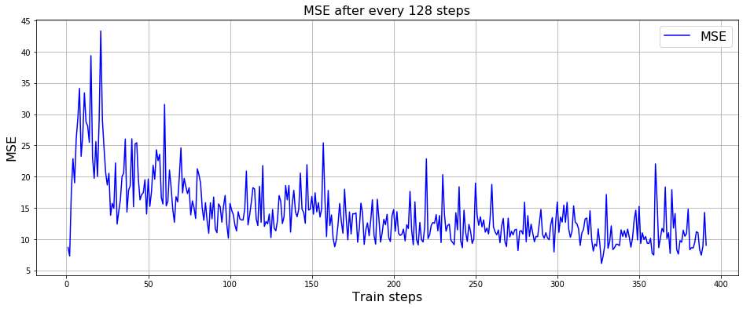

```python
plt.figure(figsize=(16,6))

plt.plot(range(1,len(hist)+1), hist, 'b', label='MSE',color="blue")
plt.title('MSE after every 128 steps',fontsize=16)
plt.xlabel('Train steps',fontsize=16)
plt.ylabel('MSE',fontsize=16)
plt.grid(True)
plt.legend(loc = 'upper right',fontsize=16)

plt.show()
```

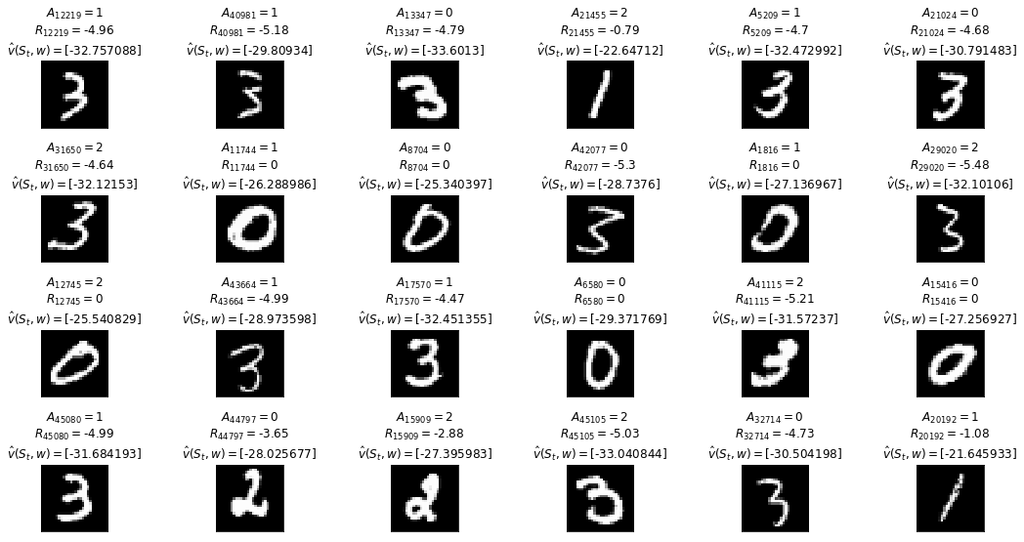

```python
k = 0
fig = plt.figure(figsize=(15,8))

ran = np.random.randint(0,len(images)-1,(1,24))

for i in ran[0]:

    V = model.predict(np.array([images[i]]))

    k += 1
    plt.subplot(4,6,k)
    plt.tight_layout()
    plt.imshow(images_[i], cmap='gray', interpolation='none')
    plt.title("$A_{" + str(i) + "}=$"+str(actions[i])+
              "\n$R_{" + str(i) + "}=$"+str(round(rewards[i],2))+
              "\n$\hat{v}(S_t,w)=$"+str(V[0]))
    plt.xticks([])
    plt.yticks([])

plt.show()
```